# HB1103 Bongo Data

Libraries

`r`r library(tidyverse) library(lubridate)

Reading in data.

`r`r dta_bg <- read_csv(_20180604_edit.csv)

Showing all column names and checking date format.

`r`r names(dta_bg)

```
 [1] \opsid\                        \zplk_pk_seq\                  \taxa_004\
 [4] \cruise_name\                  \station\                      \event_number\
 [7] \net_number\                   \zoo_aliquot\                  \zooplankton_count\
[10] \conc_10m2\                    \conc_100m3\                   \vial_number\
[13] \zoo_stage_000\                \zoo_stage_013\                \zoo_stage_020\
[16] \zoo_stage_021\                \zoo_stage_022\                \zoo_stage_023\
[19] \zoo_stage_024\                \zoo_stage_028\                \zoo_stage_029\
[22] \zoo_stage_030\                \zoo_stage_050\                \zoo_stage_051\
[25] \zoo_stage_054\                \zoo_stage_999\                \net_pk_seq\
[28] \gear\                         \gear_volume_filtered\         \sample_jar_count\
[31] \sample_type\                  \flowmeter_calibration_factor\ \flowmeter_revolutions\
[34] \flag_region\                  \flag_clogging\                \net_comment\
[37] \event_pk_seq\                 \operation\                    \event_date\
[40] \formated_event_date\          \latitude\                     \longitude\
[43] \region\                       \region_nvl\                   \plankton_stratum\
[46] \groundfish_stratum\           \surface_temperature\          \surface_temperature_nvl\
[49] \tow_profile\                  \tow_protocol\                 \tow_maximum_depth\
[52] \bottom_depth_max_wire_out\    \bio_volume_zoo\               \bio_volume_zoo_1m2\
[55] \bio_volume_zoo_100m3\         \bio_volume_large_conc_1m2\    \bio_volume_large_conc_100m3\
[58] \total_zoo_count\              \total_large_zoo_count\        \total_large_zoo_length\
[61] \large_zoo_mean_length\        \taxa_name\
```

And checking the data format.

`r`r head(dta_bg$formated_event_date)

```
[1] \6/4/2011 9:07\ \6/4/2011 9:07\ \6/4/2011 9:07\ \6/4/2011 9:07\ \6/4/2011 9:07\ \6/4/2011 9:07\
```

Initial cleaning.

`r`r dta_bg <- dta_bg %>% mutate(DT_UTC = mdy_hm(formated_event_date), tz = , Date = date(mdy_hm(formated_event_date))) %>% arrange(DT_UTC) %>% # to put in time-order mutate( leg = factor(case_when(Date <= ymd(011-06-22) ~ 1, Date >= ymd(011-06-27) & Date <= ymd(011-07-15) ~ 2, Date >= ymd(011-07-20) ~ 3))) dta_bg %>% group_by(leg) %>% summarize(`Number of Stations per Leg` = n_distinct(station)) %>% ungroup()

| leg | Number of Stations per Leg |
| --- | --- |
| 1 | 30 |
| 2 | 30 |
| 3 | 25 |

Here I’m stripping the date from the datetime to look at how many stations were during certing times of the day. Not really sure it will work as is.

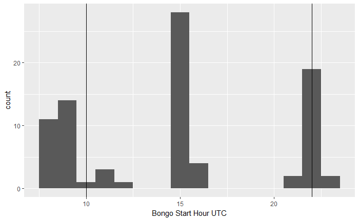

Reading in functional group data. I initally grouped the critters and Nadine checked them for me.

`r`r fnct_grp <- read_csv(_fnct_grp_from_Nadine.csv)

Joining the functional group file to the data file.

`r`r dta_bg_jn <- dta_bg %>%  
left_join(fnct_grp, by = _name) dta_bg_jn %>% group_by(functional_group) %>% summarise(cnt = n()) %>% ungroup()

| functional_group | cnt |
| --- | --- |
| Calanus | 191 |
| Centropages | 148 |
| Chaetognaths | 108 |
| crap | 19 |
| Euphausiids | 113 |
| fish | 51 |
| gelatinous | 233 |
| OIT | 499 |
| Other copepods | 1359 |
| Pteropod | 80 |

[output cut: 1 more lines]

Oops… where did the NAs come from? (Check the Next or ‘2’ button if you don’t see the NAs)

`r`r dta_bg_jn %>% filter(is.na(functional_group)) %>% select(taxa_name, event_number)

| taxa_name | event_number |
| --- | --- |
| Paguridea | 301 |
| Paguridea | 421 |
| Paguridea | 681 |
| Paguridea | 721 |
| Paguridea | 961 |

Well, at least they are all the same taxa name.

Fixing the NAs in the taxa name.

`r`r dta_bg_jn <- dta_bg_jn %>% mutate(functional_group = ifelse(taxa_name == ‘Paguridea’, ‘OIT’, functional_group)) dta_bg_jn %>% group_by(functional_group) %>% summarise(cnt = n()) %>% ungroup()

| functional_group | cnt |
| --- | --- |
| Calanus | 191 |
| Centropages | 148 |
| Chaetognaths | 108 |
| crap | 19 |
| Euphausiids | 113 |
| fish | 51 |
| gelatinous | 233 |
| OIT | 504 |
| Other copepods | 1359 |
| Pteropod | 80 |

Time for a little ArcGIS to determine transects and when EK60 data were collected (daytime). Going to group by station and export.

`r`r library(sp) library(rgdal)

[figure not shown]

`r`r #turn time into a character column to bring into ArcGIS. bg_stn_df <- bg_stn %>% mutate(DT_UTC = as.character(DT)) %>% select(DT_UTC, leg, station, lat, lon) data.frame() r

head(bg_stn_df)

`r`r bg_coords <- cbind(bg_stn_df$lon, bg_stn_df$lat) #creating coordinate list row.names(bg_coords) <- 1:nrow(bg_coords) #adding index values to rows  
str(bg_coords) #compact summary of object

```
 num [1:85, 1:2] -69.1 -69.8 -70.4 -70.8 -71.3 ...
 - attr(*, \dimnames\)=List of 2
  ..$ : chr [1:85] \1\ \2\ \3\ \4\ ...
  ..$ : NULL
```

`r`r head(bg_coords)

```
      [,1]    [,2]
1 -69.0650 40.2717
2 -69.7733 39.8317
3 -70.3850 40.2683
4 -70.7683 39.7750
5 -71.3450 39.8517
6 -72.0483 39.6550
```

`r`r crs_var <- CRS(+proj=longlat +ellps=WGS84) #adding WGS84 geoid, ‘CRS’ comes from sp or rgdal package bg_sp <- SpatialPoints(bg_coords, proj4string = crs_var) #turing CTD into SpatialPoints class object, S4 summary(bg_sp)

```
Object of class SpatialPoints
Coordinates:
               min      max
coords.x1 -74.8483 -64.7533
coords.x2  36.5717  41.9633
Is projected: FALSE
proj4string : [+proj=longlat +ellps=WGS84]
Number of points: 85
```

`r`r bbox(bg_sp) #returns bounding box

```
               min      max
coords.x1 -74.8483 -64.7533
coords.x2  36.5717  41.9633
```

`r`r proj4string(bg_sp) #returns the projection and ellispoid

```
[1] \+proj=longlat +ellps=WGS84\
```

`r`r # turn the data into a spatial points data frame with data frame and coordinates list bg_spdf <- SpatialPointsDataFrame(bg_coords, bg_stn_df, proj4string = crs_var, match.ID = TRUE)  
names(bg_spdf)

```
[1] \DT_UTC\  \leg\     \station\ \lat\     \lon\
```

`r`r ##### write spatial data frame to shapefile#### writeOGR(bg_spdf, ://Users//ealab//Documents//ArcGIS//AMAPPS//shp_from_R, layer=_R_shp,driver=Shapefile, verbose=TRUE)

[output not shown]

`r`r #Import the shapefile to file geodatabase, then convert DT from text to datetime using ‘Convert Time Field’

[output not shown]

summary(dta_bg$DT_UTC)